**Neuronale Netze mit Skorch**

Dr. Matthias Hölzl

# Training Neural Networks using Skorch

Skorch is a library for PyTorch that simplifies training in a Scikit-Learn compatible way.

```python
import matplotlib.pyplot as plt
import numpy as np
import torch
import torch.nn as nn
from sklearn.datasets import fetch_openml
from sklearn.metrics import (
    accuracy_score,
    balanced_accuracy_score,
    f1_score,
    precision_score,
    recall_score,
)
from sklearn.model_selection import train_test_split
from sklearn.preprocessing import StandardScaler
from skorch import NeuralNetClassifier
```

```python
np.set_printoptions(precision=1)
```

```python
mnist = globals().get("mnist") or fetch_openml("mnist_784", version=1)
```

## Transforming the data:

- Neural nets generally expect their inputs as `float32` (or possibly `float16`) values.
- `skorch` expects classes to be stored as `int64` values.
- We change the type of the arrays accordingly.

```python
x = mnist.data.to_numpy().reshape(-1, 1, 28, 28).astype(np.float32)
y = mnist.target.to_numpy().astype(np.int64)
print("Shape of x:", x.shape, "- type of x:", x.dtype)
print("Shape of y:", y.shape, "- type of y:", y.dtype)
```

```
Shape of x: (70000, 1, 28, 28) - type of x: float32
Shape of y: (70000,) - type of y: int64
```

```python
x_train, x_test, y_train, y_test = train_test_split(
    x, y, test_size=10_000, random_state=42
)
print("Shape of x train:", x_train.shape, "- shape of y_train:", y_train.shape)
print("Shape of x test:", x_test.shape, "- shape of y_test:", y_test.shape)
```

```
Shape of x train: (60000, 1, 28, 28) - shape of y_train: (60000,)
Shape of x test: (10000, 1, 28, 28) - shape of y_test: (10000,)
```

## Normalize / Standardize

- Neural networks generally prefer their input to be in the range $(0, 1)$ or $(-1, 1)$.
- We need to convert the integer array to floating point.

```python
print(x_train[0, 0, 20:24, 10:14])
```

```
[[255. 255. 255. 255.]
 [255. 255.  64.   0.]
 [ 64.   0.   0.   0.]
 [  0.   0.   0.   0.]]
```

- Don't use `StandardScaler` for this data, since it will scale each feature independently.

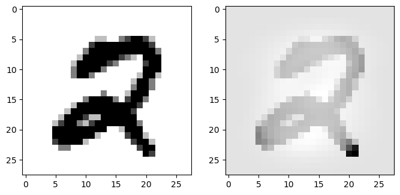

```python
scaler = StandardScaler()
x_train_scaled_with_scaler = scaler.fit_transform(x_train.reshape(-1, 28 * 28)).reshape(
    -1, 1, 28, 28
)
fig, axs = plt.subplots(ncols=2, figsize=(8, 4))
axs[0].imshow(x_train[0, 0], cmap="binary")
axs[1].imshow(x_train_scaled_with_scaler[0, 0], cmap="binary")
```

- Since we know the range of the values, we can easily perform the processing manually.

```python
x_train = x_train / 255.0
x_test = x_test / 255.0
```

```
[[1.  1.  1.  1. ]
 [1.  1.  0.3 0. ]
 [0.3 0.  0.  0. ]
 [0.  0.  0.  0. ]]
```

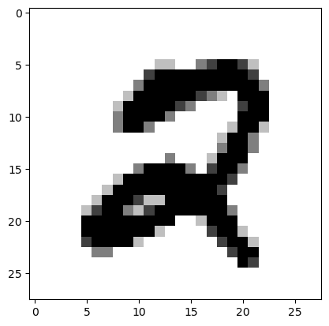

```python
print(x_train[0, 0, 20:24, 10:14])
plt.imshow(x_train[0, 0], cmap="binary")
```

## Implementing the MLP Model using Basic PyTorch Functions

- We can implement the model using basic PyTorch tensor operations, without using `nn.Linear` or other high-level modules.
- This approach demonstrates how neural network computations are built from basic operations.

```python
class MLPBasic(nn.Module):
    def __init__(self):
        super().__init__()
        # Manually initialize weights and biases
        self.W1 = nn.Parameter(torch.randn(28 * 28, 128) * 0.01)
        self.b1 = nn.Parameter(torch.zeros(128))
        self.W2 = nn.Parameter(torch.randn(128, 64) * 0.01)
        self.b2 = nn.Parameter(torch.zeros(64))
        self.W3 = nn.Parameter(torch.randn(64, 10) * 0.01)
        self.b3 = nn.Parameter(torch.zeros(10))

    def forward(self, x):
        # Flatten the input
        x = x.view(-1, 28 * 28)
        # First layer computations
        z1 = torch.matmul(x, self.W1) + self.b1
        a1 = torch.relu(z1)
        # Second layer computations
        z2 = torch.matmul(a1, self.W2) + self.b2
        a2 = torch.relu(z2)
        # Output layer computations
        z3 = torch.matmul(a2, self.W3) + self.b3
        # Do not apply Softmax here; CrossEntropyLoss does it internally
        return z3
```

```python
mlp_basic_model = MLPBasic()
```

## Implementing a Hand-Written Training Loop

- Before using `NeuralNetClassifier`, we can train our model using a manual training loop.
- This demonstrates how backpropagation and optimization steps are performed.
- We will use basic PyTorch functions to train the `MLPBasic` model.

```python
import torch
from torch.utils.data import TensorDataset, DataLoader
```

```python
# Convert numpy arrays to PyTorch tensors
x_train_tensor = torch.from_numpy(x_train)
y_train_tensor = torch.from_numpy(y_train)
x_test_tensor = torch.from_numpy(x_test)
y_test_tensor = torch.from_numpy(y_test)
```

```python
# Create a TensorDataset and DataLoader for batching
train_dataset = TensorDataset(x_train_tensor, y_train_tensor)
train_loader = DataLoader(train_dataset, batch_size=64, shuffle=True)
```

```python
# Initialize the model
model = MLPBasic()
```

```python
# Define loss function and optimizer
criterion = nn.CrossEntropyLoss()
optimizer = torch.optim.SGD(model.parameters(), lr=0.1)
```

```python
# Number of epochs
n_epochs = 10
```

```python
# Training loop
for epoch in range(n_epochs):
    running_loss = 0.0
    for inputs, labels in train_loader:
        # Zero the parameter gradients
        optimizer.zero_grad()

        # Forward pass
        outputs = model(inputs)

        # Compute loss
        loss = criterion(outputs, labels)

        # Backward pass (compute gradients)
        loss.backward()

        # Update weights
        optimizer.step()

        # Accumulate loss
        running_loss += loss.item()

    # Print statistics
    print(f"Epoch {epoch+1}/{n_epochs}, Loss: {running_loss/len(train_loader):.4f}")
```

[output not shown]

```python
# Evaluate on test set
with torch.no_grad():
    outputs = model(x_test_tensor)
    _, predicted = torch.max(outputs.data, 1)
    y_pred_manual = predicted.numpy()
```

```python
# Print evaluation metrics
def print_scores(y, y_pred):
    print(f"Accuracy:          {accuracy_score(y, y_pred) * 100:.1f}%")
    print(f"Balanced accuracy: {balanced_accuracy_score(y, y_pred) * 100:.1f}%")
    print(
        f"Precision (macro): {precision_score(y, y_pred, average='macro') * 100:.1f}%"
    )
    print(f"Recall (macro):    {recall_score(y, y_pred, average='macro') * 100:.1f}%")
    print(f"F1 (macro):        {f1_score(y, y_pred, average='macro') * 100:.1f}%")
```

```python
print_scores(y_test, y_pred_manual)
```

```
Accuracy:          97.1%
Balanced accuracy: 97.1%
Precision (macro): 97.1%
Recall (macro):    97.1%
F1 (macro):        97.1%
```

**Explanation:**

- **Data Preparation:**
  - Convert the NumPy arrays `x_train` and `y_train` to PyTorch tensors.
  - Create a `TensorDataset` and `DataLoader` for batching the training data.
- **Model Initialization:**
  - Instantiate the `MLPBasic` model.
- **Loss Function and Optimizer:**
  - Use `nn.CrossEntropyLoss` as the loss function.
  - Use Stochastic Gradient Descent (SGD) as the optimizer.
- **Training Loop:**
  - Iterate over the number of epochs.
  - For each batch in the DataLoader:
    - Zero the gradients using `optimizer.zero_grad()`.
    - Perform the forward pass to compute model outputs.
    - Compute the loss between the outputs and the target labels.
    - Perform backpropagation using `loss.backward()`, which computes the gradients.
    - Update the model parameters using `optimizer.step()`.
    - Accumulate the running loss for monitoring.
  - After each epoch, print the average loss.
- **Evaluation:**
  - Use `torch.no_grad()` to disable gradient computation during evaluation.
  - Compute the outputs on the test set.
  - Use `torch.max` to get the predicted classes.
  - Convert predictions to NumPy array for evaluation.
- **Results:**
  - Use the `print_scores` function to display evaluation metrics.

## Using `NeuralNetClassifier` for Training

- `NeuralNetClassifier` is a Scikit-Learn compatible wrapper for PyTorch models.
- It simplifies the training process by providing a high-level interface.
- We can use it to train the `MLPBasic` model.
- We can also move the training data to the GPU for faster computation.

```python
device = 'cuda' if torch.cuda.is_available() else 'cpu'
print(f'Training on {device}')
```

```
Training on cpu
```

```python
mlp_basic_model = MLPBasic()
```

```python
mlp_basic_clf = NeuralNetClassifier(
    mlp_basic_model,
    criterion=nn.CrossEntropyLoss,
    max_epochs=10,
    lr=0.1,
    iterator_train__shuffle=True,
    device=device,
)
```

```python
mlp_basic_clf.fit(x_train, y_train)
```

```
  epoch    train_loss    valid_acc    valid_loss     dur
-------  ------------  -----------  ------------  ------
      1        2.2045       0.5474        1.4521  4.1737
```

```
      2        0.7146       0.8478        0.5286  3.9021
```

```
      3        0.4157       0.8995        0.3510  3.6160
```

```
      4        0.2954       0.9223        0.2658  2.7300
```

```
      5        0.2278       0.9370        0.2159  2.3558
```

```
      6        0.1815       0.9482        0.1807  2.9748
```

```
      7        0.1528       0.9537        0.1572  2.8131
```

```
      8        0.1330       0.9542        0.1504  1.8459
```

```
      9        0.1167       0.9599        0.1318  1.5100
```

```
     10        0.1040       0.9589        0.1313  1.7398
```

```
<class 'skorch.classifier.NeuralNetClassifier'>[initialized](
  module_=MLPBasic(),
)
```

```python
y_pred_mlp_basic = mlp_basic_clf.predict(x_test)
```

```python
print_scores(y_test, y_pred_mlp_basic)
```

```
Accuracy:          95.9%
Balanced accuracy: 95.9%
Precision (macro): 96.0%
Recall (macro):    95.9%
F1 (macro):        95.9%
```

## Implementing the MLP Model using `nn.Sequential`

- `nn.Sequential` allows us to build models by specifying a sequence of layers.
- This is a simpler and more concise way to define models compared to manually coding the computations.

```python
mlp_model = nn.Sequential(
    nn.Flatten(),
    nn.Linear(28 * 28, 128),
    nn.ReLU(),
    nn.Linear(128, 64),
    nn.ReLU(),
    nn.Linear(64, 10),
    # For CrossEntropyLoss, do not apply Softmax at the end
    # nn.Softmax(dim=1),
)
```

```python
mlp_clf = NeuralNetClassifier(
    mlp_model,
    criterion=nn.CrossEntropyLoss,
    max_epochs=10,
    lr=0.1,
    iterator_train__shuffle=True,
    device=device,
)
```

```python
mlp_clf.fit(x_train, y_train)
```

```
  epoch    train_loss    valid_acc    valid_loss     dur
-------  ------------  -----------  ------------  ------
      1        0.7862       0.8968        0.3551  2.5066
```

```
      2        0.3009       0.9220        0.2699  1.4321
```

```
      3        0.2306       0.9389        0.2156  1.1162
```

```
      4        0.1842       0.9446        0.1835  1.1209
```

```
      5        0.1545       0.9530        0.1592  1.1229
```

```
      6        0.1317       0.9593        0.1364  1.3354
```

```
      7        0.1135       0.9610        0.1293  1.0900
```

```
      8        0.0993       0.9626        0.1200  1.2231
```

```
      9        0.0878       0.9677        0.1058  1.1116
```

```
     10        0.0776       0.9676        0.1071  1.1400
```

```
<class 'skorch.classifier.NeuralNetClassifier'>[initialized](
  module_=Sequential(
    (0): Flatten(start_dim=1, end_dim=-1)
    (1): Linear(in_features=784, out_features=128, bias=True)
    (2): ReLU()
    (3): Linear(in_features=128, out_features=64, bias=True)
    (4): ReLU()
    (5): Linear(in_features=64, out_features=10, bias=True)
  ),
)
```

```python
y_pred_mlp = mlp_clf.predict(x_test)
```

```python
print_scores(y_test, y_pred_mlp)
```

```
Accuracy:          96.4%
Balanced accuracy: 96.3%
Precision (macro): 96.4%
Recall (macro):    96.3%
F1 (macro):        96.3%
```

## Implementing the MLP Model using `nn.Module` (Object-Oriented Version)

- By subclassing `nn.Module`, we can define models in an object-oriented way.
- This approach provides greater flexibility, which is useful for more complex models.

```python
class MLP(nn.Module):
    def __init__(self):
        super(MLP, self).__init__()
        # Define layers
        self.flatten = nn.Flatten()
        self.hidden1 = nn.Linear(28 * 28, 128)
        self.relu1 = nn.ReLU()
        self.hidden2 = nn.Linear(128, 64)
        self.relu2 = nn.ReLU()
        self.output_layer = nn.Linear(64, 10)
        # Note: We do not include Softmax here for CrossEntropyLoss

    def forward(self, x):
        x = self.flatten(x)
        x = self.hidden1(x)
        x = self.relu1(x)
        x = self.hidden2(x)
        x = self.relu2(x)
        x = self.output_layer(x)
        return x
```

```python
mlp_model_oop = MLP()
```

```python
mlp_clf_oop = NeuralNetClassifier(
    mlp_model_oop,
    criterion=nn.CrossEntropyLoss,
    max_epochs=10,
    lr=0.1,
    iterator_train__shuffle=True,
    device=device,
)
```

```python
# mlp_clf_oop.fit(x_train, y_train)
```

```python
# y_pred_mlp_oop = mlp_clf_oop.predict(x_test)
```

```python
# print_scores(y_test, y_pred_mlp_oop)
```

## Implementing a Convolutional Neural Network (CNN) using `nn.Sequential`

- CNNs are well-suited for image data and can capture spatial hierarchies in images.
- Here, we define a simple CNN with two convolutional layers followed by fully connected layers.

```python
conv_model = nn.Sequential(
    nn.Conv2d(1, 10, kernel_size=5, stride=(2, 2)),
    nn.ReLU(),
    nn.Conv2d(10, 20, kernel_size=5, stride=(2, 2)),
    nn.ReLU(),
    nn.Flatten(),
    nn.Linear(320, 60),
    nn.ReLU(),
    nn.Linear(60, 10),
)
```

```python
conv_clf = NeuralNetClassifier(
    conv_model,
    criterion=nn.CrossEntropyLoss,
    max_epochs=20,
    lr=0.1,
    iterator_train__shuffle=True,
    device=device,
)
```

```python
# conv_clf.fit(x_train, y_train)
```

```python
# y_pred_conv = conv_clf.predict(x_test)
```

```python
# print_scores(y_test, y_pred_conv)
```

```python
conv_model = nn.Sequential(
    nn.Conv2d(
        1, 32, kernel_size=3, padding=1
    ),  # Increased filters, smaller kernel, padding
    nn.BatchNorm2d(32),  # Added batch normalization
    nn.ReLU(),
    nn.Conv2d(32, 64, kernel_size=3, padding=1),  # Increased filters
    nn.BatchNorm2d(64),
    nn.ReLU(),
    nn.MaxPool2d(2, 2),  # Added MaxPooling
    nn.Conv2d(64, 128, kernel_size=3, padding=1),  # Added another conv layer
    nn.BatchNorm2d(128),
    nn.ReLU(),
    nn.MaxPool2d(2, 2),  # Added MaxPooling
    nn.Flatten(),
    nn.Linear(128 * 7 * 7, 256),  # Adjusted input features based on conv output
    nn.ReLU(),
    nn.Dropout(0.5),  # Added dropout
    nn.Linear(256, 10),
)
```

```python
from torch.optim.lr_scheduler import StepLR
from skorch.callbacks import LRScheduler
```

```python
lr_scheduler = LRScheduler(
    policy=StepLR,         # The learning rate scheduler class
    step_size=5,           # Decay LR every 5 epochs
    gamma=0.2,             # Multiply LR by gamma
    verbose=True,          # Prints LR updates
)
```

```python
# Define the classifier with the Adam optimizer and a lower learning rate
conv_clf = NeuralNetClassifier(
    conv_model,
    criterion=nn.CrossEntropyLoss,
    optimizer=torch.optim.Adam,       # Use the Adam optimizer
    max_epochs=20,
    lr=0.001,                         # Lower learning rate for Adam
    device=device,
    callbacks=[lr_scheduler],         # Add the LR scheduler callback
    iterator_train__shuffle=True,
    verbose=1,
)
```

```python
# conv_clf.fit(x_train, y_train)
```

```python
# y_pred_conv = conv_clf.predict(x_test)
```

```python
# print_scores(y_test, y_pred_conv)
```